# Healing or Harming? The Silent Crisis in Healthcare Sanitation

A UNICEF Data Investigation into Sanitation in Health Facilities Worldwide

```python
indicator2 = pl.read_csv("unicef_indicator_2.csv")
metadata   = pl.read_csv("unicef_metadata.csv")

print(f"Indicator 2  :  {indicator2.shape[0]} rows  x  {indicator2.shape[1]} columns")
print(f"Metadata     :  {metadata.shape[0]} rows  x  {metadata.shape[1]} columns")
print(f"Countries    :  {indicator2.select('country').n_unique()} unique")
print(f"Year range   :  {indicator2.select('time_period').min().item()} - {indicator2.select('time_period').max().item()}")
```

```
Indicator 2  :  1822 rows  x  14 columns
Metadata     :  13715 rows  x  15 columns
Countries    :  119 unique
Year range   :  2000 - 2023
```

```python
print("=== obs_value summary (Indicator 2) ===")
print(indicator2.select("obs_value").describe())

print("\n=== Null counts per column ===")
nulls = indicator2.null_count()
for col in nulls.columns:
    n = nulls[col].item()
    if n > 0:
        print(f"  {col}: {n} nulls")
print("  (zero nulls in key columns: country, alpha_3_code, time_period, obs_value)")
```

```
=== obs_value summary (Indicator 2) ===
shape: (9, 2)
┌────────────┬───────────┐
│ statistic  ┆ obs_value │
│ ---        ┆ ---       │
│ str        ┆ f64       │
╞════════════╪═══════════╡
│ count      ┆ 1822.0    │
│ null_count ┆ 0.0       │
│ mean       ┆ 8.497795  │
│ std        ┆ 13.506428 │
│ min        ┆ 0.0       │
│ 25%        ┆ 0.0       │
│ 50%        ┆ 2.741285  │
│ 75%        ┆ 10.9      │
│ max        ┆ 71.989305 │
└────────────┴───────────┘

=== Null counts per column ===
  alpha_2_code: 9 nulls
  unit_multiplier: 1822 nulls
  observation_status: 1822 nulls
  observation_confidentaility: 1822 nulls
  time_period_activity_related_to_when_the_data_are_collected: 1822 nulls
  (zero nulls in key columns: country, alpha_3_code, time_period, obs_value)
```

```python
ind2_total = (
    indicator2
    .filter(pl.col("sex") == "Total")
    .select(["country", "alpha_3_code", "time_period", "obs_value"])
)

country_avg = (
    ind2_total
    .group_by("country", "alpha_3_code")
    .agg(pl.col("obs_value").mean().alias("avg_no_sanitation"))
    .sort("avg_no_sanitation", descending=True)
)

meta_clean = (
    metadata
    .select(["country", "alpha_3_code", "year",
             "Life expectancy at birth, total (years)",
             "GDP per capita (constant 2015 US$)",
             "Population, total"])
    .rename({
        "Life expectancy at birth, total (years)": "life_exp",
        "GDP per capita (constant 2015 US$)": "gdp_pc",
        "Population, total": "pop"
    })
    .filter(pl.col("year") >= 2015)
)

scatter_df = (
    ind2_total
    .filter(pl.col("time_period") >= 2015)
    .join(meta_clean,
          left_on=["alpha_3_code", "time_period"],
          right_on=["alpha_3_code", "year"],
          how="inner")
    .drop("country_right")
    .filter(pl.col("life_exp").is_not_null())
    .filter(pl.col("obs_value").is_not_null())
)

ts_global = (
    ind2_total
    .group_by("time_period")
    .agg(pl.col("obs_value").mean().alias("global_mean"))
    .sort("time_period")
)

country_avg_pd = country_avg.to_pandas()
scatter_pd     = scatter_df.to_pandas()
ts_pd          = ts_global.to_pandas()
top15          = country_avg_pd.head(15)

print("Data transformation complete")
print(f"  country_avg  : {country_avg_pd.shape[0]} countries")
print(f"  scatter_df   : {scatter_pd.shape[0]} rows (post-2015, joined with metadata)")
print(f"  ts_global    : {ts_pd.shape[0]} years")
print(f"  top 15 worst : {top15.iloc[0]['country']} at {round(top15.iloc[0]['avg_no_sanitation'],1)}%")
```

```
Data transformation complete
  country_avg  : 119 countries
  scatter_df   : 847 rows (post-2015, joined with metadata)
  ts_global    : 24 years
  top 15 worst : Kyrgyzstan at 63.5%
```

UNICEF Data 2025

UNICEF DATA REPORT · GLOBAL HEALTH

Healing or Harming?

The Silent Crisis in Healthcare Sanitation Worldwide

**Indicator** Proportion of health facilities with no sanitation service **Coverage** 119 countries **Period** 2000–2023 **Source** UNICEF Indicator 2 + World Bank

119 countries covered

63.5% worst country (Kyrgyzstan)

2000–2023 years of data

0 meaningful improvements seen

## The Crisis Nobody Talks About

When we think of hospitals and clinics, we imagine places of healing sterile, safe, life-saving. But for **hundreds of millions of people** across the developing world, the reality is starkly different. The very facilities meant to protect life are operating without the most basic necessity: **clean sanitation**.

“A healthcare facility without proper sanitation is not a place of healing it is a place of risk.” UNICEF/WHO Joint Monitoring Programme

This report examines a deeply troubling UNICEF indicator the *percentage of healthcare facilities with no sanitation service*. Using data from **119 countries spanning 2000 to 2023**, we uncover a global crisis hiding in plain sight, one that disproportionately affects the world’s most vulnerable populations.

## Why Sanitation in Healthcare Matters

Sanitation in healthcare facilities is not a luxury. It is a **fundamental prerequisite** for:

- **Infection prevention** - absence of handwashing facilities allows pathogens to spread, particularly dangerous in post-surgical and maternity wards
- **Maternal and child safety** - unsafe birth environments caused by poor sanitation contribute to neonatal infections and maternal mortality
- **Staff dignity and protocol adherence** - healthcare workers cannot follow hygiene protocols without proper facilities
- **Public trust** - communities that distrust facilities due to poor conditions avoid seeking care, creating a vicious cycle of worsening health outcomes

The data reveals that in some countries, **over 60% of health facilities lack any sanitation service**. This is not a marginal problem it is a *systemic failure*.

## A World Divided: Global Sanitation Map

Section 02 · Visualisation 1 - World Map

The world map below visualises the **average percentage** of healthcare facilities with no sanitation service by country. Darker colours indicate a more severe crisis. Grey countries have no data available in the UNICEF dataset.

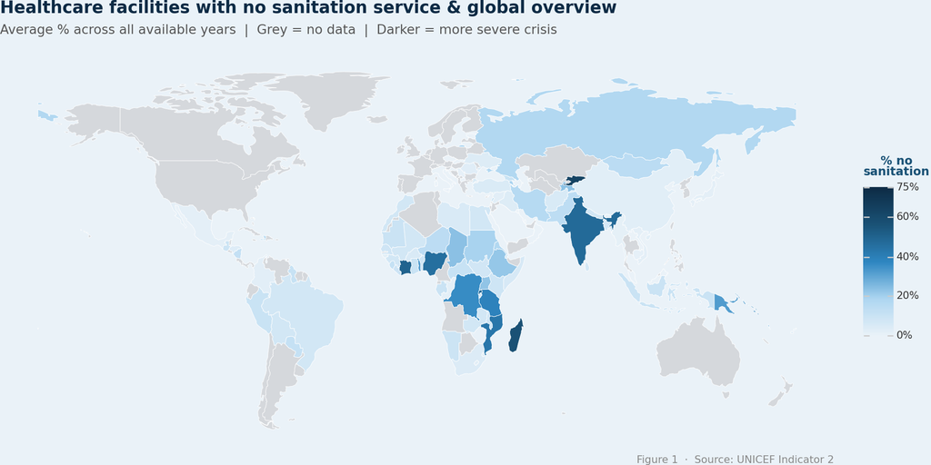

Figure 1

```python
SHAPEFILE = "/usr/local/lib/python3.12/dist-packages/pyogrio/tests/fixtures/naturalearth_lowres/naturalearth_lowres.shp"
world_gdf    = gpd.read_file(SHAPEFILE).to_crs("EPSG:4326")
world_merged = world_gdf.merge(country_avg_pd, left_on="iso_a3", right_on="alpha_3_code", how="left")

(
    ggplot(world_merged)
    + geom_map(aes(fill="avg_no_sanitation"), color="white", size=0.2)
    + scale_fill_gradientn(
        colors=["#eaf2f8", "#aed6f1", "#2e86c1", "#1a5276", "#0d2b45"],
        na_value="#d5d8dc",
        name="% no\nsanitation",
        limits=(0, 75),
        breaks=[0, 20, 40, 60, 75],
        labels=["0%", "20%", "40%", "60%", "75%"]
    )
    + coord_cartesian(xlim=(-180, 180), ylim=(-55, 85))
    + labs(
        title    = "Healthcare facilities with no sanitation service & global overview",
        subtitle = "Average % across all available years  |  Grey = no data  |  Darker = more severe crisis",
        caption  = "Figure 1  ·  Source: UNICEF Indicator 2"
    )
    + theme_void()
    + theme(
        plot_title       = element_text(size=13, weight="bold", color="#0d2b45", margin={"b": 6}),
        plot_subtitle    = element_text(size=10, color="#555555", margin={"b": 10}),
        plot_caption     = element_text(size=8,  color="#888888"),
        legend_title     = element_text(size=9,  weight="bold", color="#1a5276"),
        legend_text      = element_text(size=8,  color="#333333"),
        legend_position  = "right",
        plot_background  = element_rect(fill="#eaf2f8", color="#eaf2f8"),
        panel_background = element_rect(fill="#eaf2f8", color="#eaf2f8"),
        figure_size      = (10, 5)
    )
)
```

## The Worst Offenders: Top 15 Countries

Section 03 · Visualisation 2-Bar Chart

Which countries are most affected? The bar chart below ranks the **top 15 countries** by average percentage of healthcare facilities lacking sanitation. Each bar represents the mean across all years of available data, with the gradient darkening for the worst-performing countries.

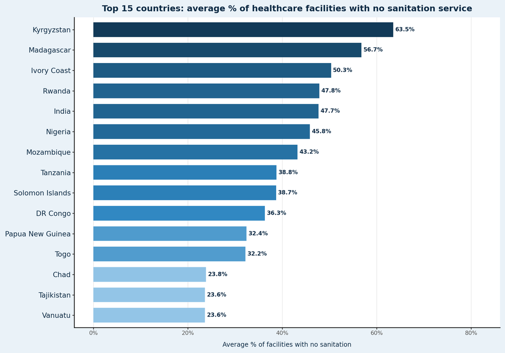

Figure 2: Figure 2 · Top 15 countries by average % of healthcare facilities with no sanitation service

```python
top15_sorted = top15.sort_values("avg_no_sanitation", ascending=True).copy()
top15_sorted["label"] = top15_sorted["avg_no_sanitation"].round(1).astype(str) + "%"
short_names = {
    "Tanzania, United Republic of": "Tanzania",
    "Congo, the Democratic Republic of the": "DR Congo"
}
top15_sorted["country"] = top15_sorted["country"].replace(short_names)
top15_sorted["country"] = pd.Categorical(
    top15_sorted["country"],
    categories=top15_sorted["country"].tolist(),
    ordered=True
)

(
    ggplot(top15_sorted, aes(x="country", y="avg_no_sanitation", fill="avg_no_sanitation"))
    + geom_col(width=0.72)
    + geom_text(
        aes(label="label"),
        ha="left", nudge_y=0.4, size=8, color="#0d2b45", fontweight="bold"
    )
    + scale_fill_gradientn(
        colors=["#aed6f1", "#2e86c1", "#1a5276", "#0d2b45"],
        limits=(20, 70),
        guide=None
    )
    + scale_y_continuous(
        limits=(0, 82),
        breaks=[0, 20, 40, 60, 80],
        labels=["0%", "20%", "40%", "60%", "80%"]
    )
    + coord_flip()
    + labs(
        title    = "Top 15 countries: average % of healthcare facilities with no sanitation service",
        x        = "",
        y        = "Average % of facilities with no sanitation",
    )
    + theme_classic()
    + theme(
        plot_title         = element_text(size=12, weight="bold", color="#0d2b45", margin={"b": 6}),
        plot_subtitle      = element_text(size=9,  color="#555555", margin={"b": 8}),
        plot_caption       = element_text(size=8,  color="#888888"),
        axis_text_y        = element_text(size=10, color="#0d2b45"),
        axis_text_x        = element_text(size=8,  color="#555555"),
        axis_title_x       = element_text(size=9,  color="#0d2b45", margin={"t": 8}),
        panel_grid_major_x = element_line(color="#dddddd", size=0.5),
        panel_grid_major_y = element_blank(),
        plot_background    = element_rect(fill="#eaf2f8", color="#eaf2f8"),
        panel_background   = element_rect(fill="white"),
        figure_size        = (10, 7)
    )
)
```

**Kyrgyzstan** leads with a staggering **63.5%** nearly two-thirds of its health facilities offer no sanitation service. **Madagascar** and **Ivory Coast** follow closely. What is particularly alarming is that **India**, the world’s most populous country, sits fifth on this list meaning the absolute number of people exposed to this risk is enormous. Each percentage point here represents not just a statistic, but *real patients, real risks, and real preventable deaths*.

## The Life Expectancy Connection

Section 04 · Visualisation 3-Scatterplot with Regression

Is there a relationship between poor healthcare sanitation and life expectancy? The scatterplot below examines this directly, plotting the **percentage of unsanitised health facilities against life expectancy at birth**, with a linear regression line. Each dot represents one country (mean values, post-2015 data merged with World Bank metadata).

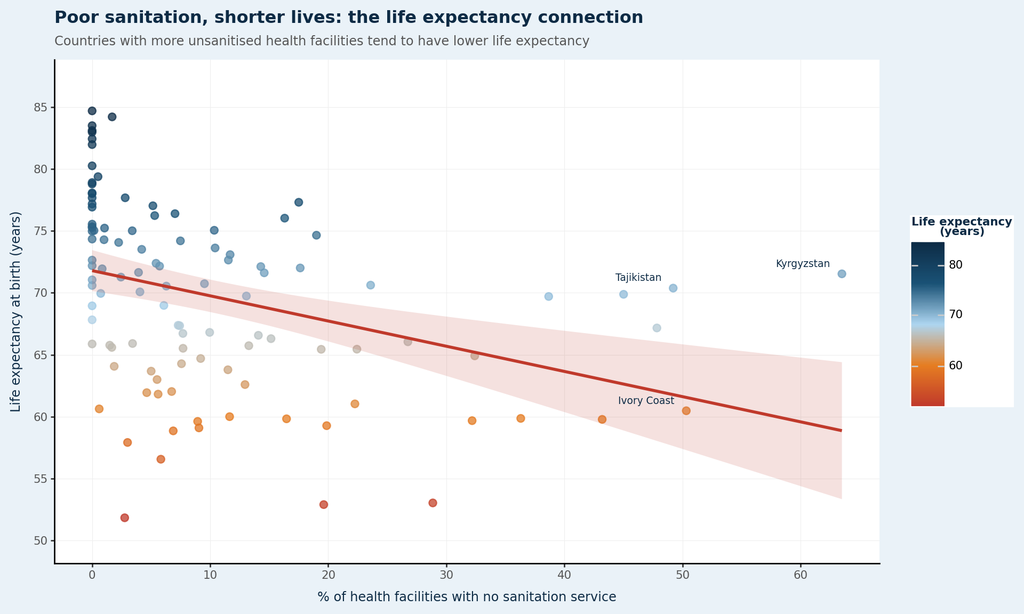

Figure 3: Figure 3 · % no sanitation vs life expectancy at birth · Red line = linear regression · Each point = one country (mean values)

```python
scatter_agg = (
    scatter_pd
    .groupby("country")
    .agg(obs_value=("obs_value", "mean"), life_exp=("life_exp", "mean"))
    .reset_index()
    .dropna(subset=["obs_value", "life_exp"])
    .query("life_exp >= 50")
)
extremes = scatter_agg.nlargest(3, "obs_value")

(
    ggplot(scatter_agg, aes(x="obs_value", y="life_exp"))
    + geom_point(aes(color="life_exp"), size=2.5, alpha=0.75)
    + geom_smooth(method="lm", color=RED, fill=RED, alpha=0.15, size=1.2)
    + geom_text(
        data=extremes,
        mapping=aes(x="obs_value", y="life_exp", label="country"),
        size=7, color="#0d2b45", nudge_y=0.8, nudge_x=-1, ha="right"
    )
    + scale_color_gradientn(
        colors=["#c0392b", "#e67e22", "#aed6f1", "#1a5276", "#0d2b45"],
        name="Life expectancy\n(years)"
    )
    + scale_x_continuous(
        name="% of health facilities with no sanitation service",
        breaks=[0, 10, 20, 30, 40, 50, 60, 70]
    )
    + scale_y_continuous(
        name="Life expectancy at birth (years)",
        breaks=[50, 55, 60, 65, 70, 75, 80, 85],
        limits=(50, 87)
    )
    + labs(
        title    = "Poor sanitation, shorter lives: the life expectancy connection",
        subtitle = "Countries with more unsanitised health facilities tend to have lower life expectancy",
    )
    + theme_classic()
    + theme(
        plot_title       = element_text(size=12, weight="bold", color="#0d2b45", margin={"b": 6}),
        plot_subtitle    = element_text(size=9,  color="#555555", margin={"b": 8}),
        plot_caption     = element_text(size=8,  color="#888888"),
        axis_text        = element_text(size=8,  color="#555555"),
        axis_title       = element_text(size=9,  color="#0d2b45"),
        legend_title     = element_text(size=8,  weight="bold", color="#0d2b45"),
        legend_text      = element_text(size=8),
        panel_grid_major = element_line(color="#eeeeee", size=0.4),
        plot_background  = element_rect(fill="#eaf2f8", color="#eaf2f8"),
        panel_background = element_rect(fill="white"),
        figure_size      = (10, 6)
    )
)
```

## A Decade of Stagnation

Section 05 · Visualisation 4 - Time-Series

Has the situation improved over time? The time-series chart tracks the **global average** percentage of healthcare facilities with no sanitation service from 2000 to 2023. The dashed red line marks the *period average* of **8.0%**. The amber dotted line marks the **2020 COVID-19 pandemic** year.

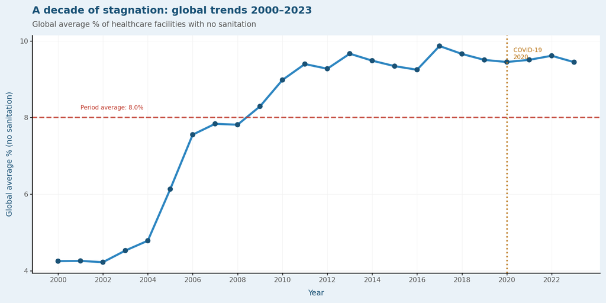

Figure 4: Figure 4 · Global average % of healthcare facilities with no sanitation (2000-2023) · Dashed red = period average 8.0% · Amber dotted = COVID-19 2020 · 119 countries

```python
(
    ggplot(ts_pd, aes(x="time_period", y="global_mean"))
    + geom_line(color=TEAL, size=1.4)
    + geom_point(color=NAVY, size=2.5)
    + geom_hline(
        yintercept=ts_pd["global_mean"].mean(),
        linetype="dashed", color=RED, size=0.9, alpha=0.8
    )
    + geom_vline(
        xintercept=2020,
        linetype="dotted", color=AMBER, size=1, alpha=0.9
    )
    + annotate(
        "text", x=2020.3, y=ts_pd["global_mean"].max() - 0.2,
        label="COVID-19\n2020", size=7, color=AMBER, ha="left"
    )
    + annotate(
        "text", x=2001, y=ts_pd["global_mean"].mean() + 0.25,
        label="Period average: 8.0%", size=7, color=RED, ha="left"
    )
    + scale_x_continuous(
        name="Year",
        breaks=list(range(2000, 2024, 2))
    )
    + scale_y_continuous(
        name="Global average % (no sanitation)",
        breaks=[4, 6, 8, 10, 12]
    )
    + labs(
        title    = "A decade of stagnation: global trends 2000\u20132023",
        subtitle = "Global average % of healthcare facilities with no sanitation",
    )
    + theme_classic()
    + theme(
        plot_title       = element_text(size=12, weight="bold", color=NAVY, margin={"b": 6}),
        plot_subtitle    = element_text(size=9,  color="#555555", margin={"b": 8}),
        plot_caption     = element_text(size=8,  color="#888888"),
        axis_text        = element_text(size=8,  color="#555555"),
        axis_title       = element_text(size=9,  color=NAVY),
        panel_grid_major = element_line(color="#eeeeee", size=0.4),
        plot_background  = element_rect(fill="#eaf2f8", color="#eaf2f8"),
        panel_background = element_rect(fill="white"),
        figure_size      = (10, 5)
    )
)
```

## What Needs to Happen

The data presented in this report makes one thing undeniable: **healthcare sanitation is a global emergency that is not being treated as one.**

Priority Actions

1. **Targeted investment** in the 15 worst-affected countries especially Kyrgyzstan, Madagascar, India, and Nigeria must become a UNICEF funding priority
2. **Routine data collection** must be strengthened in countries with data gaps (shown in grey on the world map) to ensure accountability
3. **Life expectancy targets cannot be met** without addressing healthcare sanitation this is a core determinant of health, not a peripheral issue

Key Numbers from the Data

63.5%Kyrgyzstan-worst globally

119countries with data

23 yrszero meaningful decline

The world cannot call itself committed to universal healthcare while millions of patients enter facilities that lack a working toilet. **The data demands action. The question is whether the world has the will to deliver it.**

## About This Report

| Detail | Value |
| --- | --- |
| **Indicator** | Proportion of health care facilities with no sanitation service |
| **Supporting data** | World Bank development metadata life expectancy, GDP per capita, population |
| **Countries covered** | 119 countries across all inhabited continents |
| **Time period** | 2000 – 2023 (24 years) |
| **Visualisation tools** | plotnine (all 4 charts) · GeoPandas (world map) · Polars (data transformation) |
| **YAML options** | embed-resources: true · code-fold: true · theme: flatly · toc: false · page-layout: article |
| **Hashpipe options** | #\| label · #\| fig-cap · #\| fig-width · #\| fig-height · #\| echo · #\| include |
| **Hosted on** | GitHub Pages |

UNICEF Data 2025 Healthcare Sanitation 119 Countries Polars plotnine Quarto

Healing or Harming? · UNICEF Data Report · 2025